# Harvesting the Rain: The Adoption of Environmental Technologies in the Sahel

Aker and Jack

APEC 8990

Paper Presentations

October 1, 2024

## Motivation

- Fixed costs of investment may deter adoption of environmental technology
  - Information, liquidity, credit constraints
- Desertification of the Sahel has led to a drop in agricultural production.
- How can we increase adoption of technology for climate adaptation?
  - Low adoption rates of rainwater harvesting technology $\sim$ 10% in Niger

## Motivation

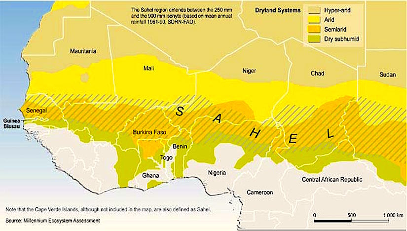

## Research Question

> Can Rainwater Harvesting (RWH) techniques be a climate adaptation that mitigates climate shocks?

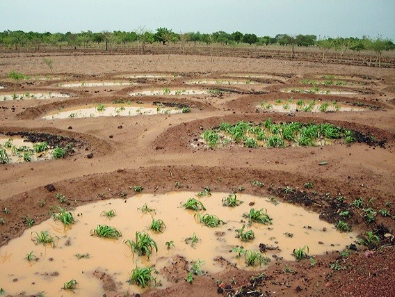

## Overview

- Findings:
  - Training massively increased adoption with lasting effects over 3 years
  - Intensive of adoption increased with 34 demi-lunes per farmer in treatment over control
  - Information and liquidity for upfront investments are the binding constraints
  - Treatment hired more labor, and increased extensification and agricultural production
  - Profitable tech adoption: revenue ($34) > costs ($30)

## Data

### Demi-Lunes (Technology)

Cost: $80 USD (14% of per capita income)

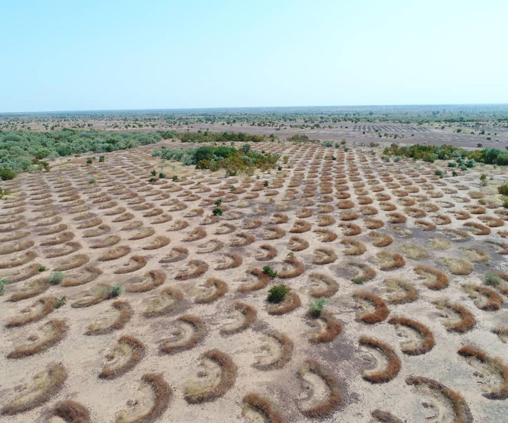

## Data

### Niger 2018 - 2021

1. Villages
   - 180 villages in Zinder region
   - Elibility:
     - Degraded land
     - No chieftancy disputes & has own chief
2. Households
   - 2,861 households
   - 670 neighoring households for spillover sample

## Empirical Strategy

### Agricultural Calendar

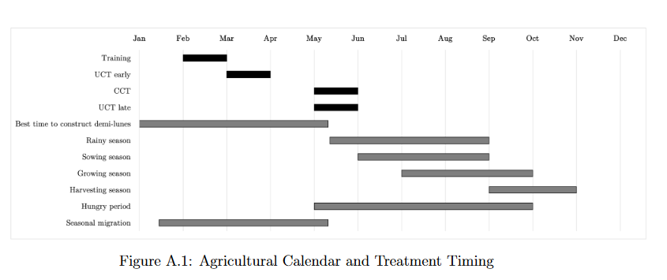

## Empirical Strategy

### Treatment Assignments

- 5 total treatment arms

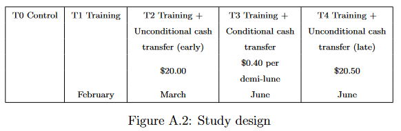

## Empirical Strategy

### Clustered RCT

- $T$: Treatment arm $j$

$$Y_{iv} = \alpha + \sum_{j = 1}^4 \beta_j T_v^j + \gamma X'_{i0} + \theta_v + \varepsilon_iv$$

## Results

### Adoption Rates

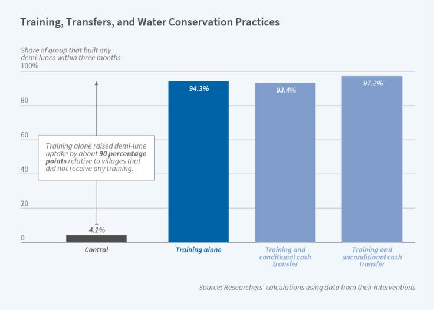

## Results

### Spillover Adoption

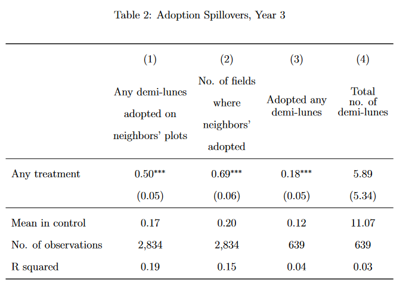

## Results

### Labor Effects

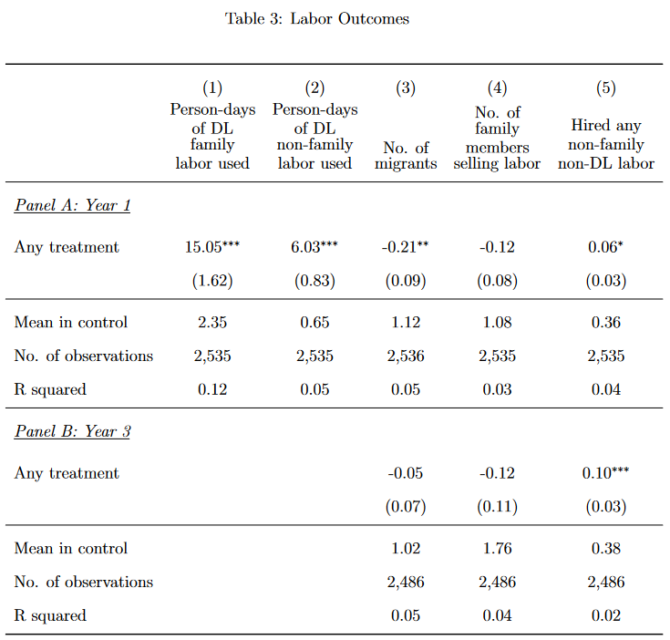

## Results

### Agricultural Production

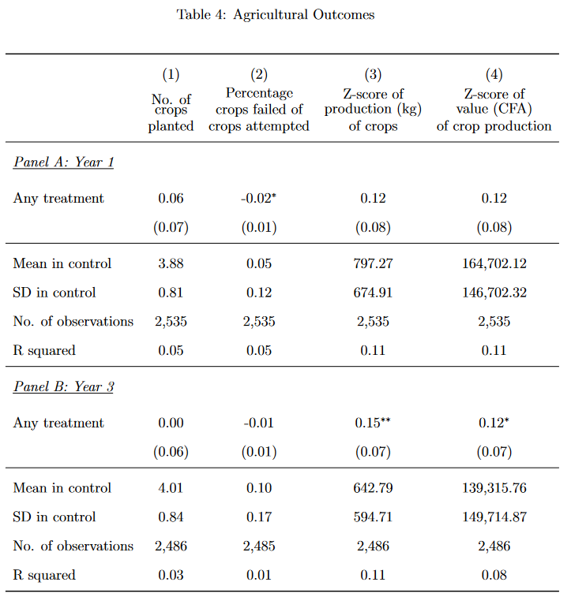

## Results

### Land Use and Soil Quality

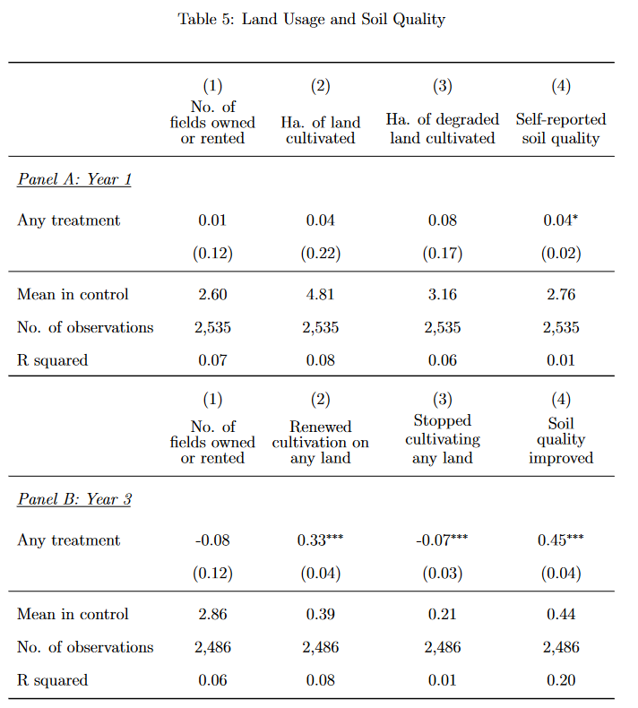

## Summary

- Upfront investment and information constraints are main barriers to climate adaptation adoption
- RWH is a profitiable technology for reversing desertification and increasing agricultural extensification
- Distinct from past literature on one-day trainings (Magruder, 2018; Macours, 2019)
  - Extensive margin adoption: 2,000%